# Описательный анализ данных

July 3, 2018

Подключаем нужные пакеты

Для выполнения задания загружаем файл obsl и сохранен в переменной под названием `ob`.

Для этого воспользовались функцией `import` из пакета `rio`. Затем проверим, что данные загрузились с помощью команд `glimpse`, `head` и `tail`.

```r
ob <- import('C:/Users/ASUS/Desktop/r_course/data/obsl.sav')
glimpse(ob)
```

```
## Observations: 1,396
## Variables: 14
## $ MEST    <chr> "1", "1", "1", "1", "1", "1", "1", "1", "1", "1", "1",...
## $ CHLICN  <dbl> 2, 1, 4, 3, 2, 2, 2, 1, 1, 2, 2, 2, 3, 2, 2, 2, 1, 2, ...
## $ DOXODSN <dbl> 177670.07, 141512.22, 199999.26, 169907.29, 141838.19,...
## $ DOXODN  <dbl> 88835.04, 141512.22, 49999.82, 56635.76, 70919.10, 723...
## $ POTRAS  <dbl> 112010.07, 124712.22, 151272.73, 112667.29, 86268.44, ...
## $ PROD    <dbl> 55786.34, 34562.61, 60593.75, 63706.76, 56668.96, 4922...
## $ NEPROD  <dbl> 33969.00, 39434.83, 40214.55, 10455.00, 11635.26, 1705...
## $ USLUG   <dbl> 21841.41, 19564.96, 30751.43, 13700.00, 17964.22, 3176...
## $ NALOG   <dbl> 15660.00, 11700.00, 26226.53, 6240.00, 10469.75, 11700...
## $ OBPL    <dbl> 92, 34, 73, 92, 53, 73, 53, 73, 37, 73, 76, 34, 53, 73...
## $ RPC     <dbl> 1, 0, 1, 1, 1, 1, 1, 1, 0, 1, 1, 1, 1, 1, 0, 0, 0, 0, ...
## $ RAVT    <dbl> 1, 0, 0, 1, 0, 0, 1, 1, 0, 1, 0, 1, 0, 0, 0, 1, 0, 0, ...
## $ DOSINT  <dbl> 1, 2, 1, 1, 1, 1, 1, 1, 2, 1, 1, 1, 1, 1, 2, 2, 2, 2, ...
## $ FINPOL  <dbl> 3, 3, 4, 3, 3, 4, 3, 4, 3, 4, 3, 4, 4, 3, 3, 3, 2, 3, ...
```

```r
head(ob)
```

```
##   MEST CHLICN  DOXODSN    DOXODN    POTRAS     PROD   NEPROD    USLUG
## 1    1      2 177670.1  88835.04 112010.07 55786.34 33969.00 21841.41
## 2    1      1 141512.2 141512.22 124712.22 34562.61 39434.83 19564.96
## 3    1      4 199999.3  49999.82 151272.73 60593.75 40214.55 30751.43
## 4    1      3 169907.3  56635.76 112667.29 63706.76 10455.00 13700.00
## 5    1      2 141838.2  70919.10  86268.44 56668.96 11635.26 17964.22
## 6    1      2 144745.4  72372.72  98045.44 49224.22 17056.20 31765.02
##      NALOG OBPL RPC RAVT DOSINT FINPOL
## 1 15660.00   92   1    1      1      3
## 2 11700.00   34   0    0      2      3
## 3 26226.53   73   1    0      1      4
## 4  6240.00   92   1    1      1      3
## 5 10469.75   53   1    0      1      3
## 6 11700.00   73   1    0      1      4
```

```r
tail(ob)
```

```
##      MEST CHLICN  DOXODSN    DOXODN   POTRAS      PROD   NEPROD     USLUG
## 1391    1      3 594433.0 198144.33 529433.0  87394.30 254400.0 123900.00
## 1392    1      5 315841.7  63168.34 256841.7  89083.70  61035.0  73736.57
## 1393    1      5 315841.7  63168.34 256841.7  89083.70  61035.0  73736.57
## 1394    1      2 147917.3  73958.64 130517.3  98260.76   5540.0  23049.90
## 1395    1      4 596106.8 149026.71 901906.8 102139.62 716045.0  52838.53
## 1396    1      5 399529.1  79905.82 358729.1 105166.89 126156.8 127405.42
##      NALOG OBPL RPC RAVT DOSINT FINPOL
## 1391 65000   67   1    2      1      4
## 1392 39000   44   1    2      1      3
## 1393 39000   44   1    2      1      3
## 1394 17400   40   0    0      2      3
## 1395 44200   44   1    2      1      3
## 1396 40800   48   1    0      1      3
```

Переменные

1 MEST Тип населенного пункта (1-городской, 2- сельский) - качественная 2 CHLICN Число наличных лиц в домохозяйстве - количественная 3 DOXODSN Денежный доход - количественная 4 DOXODN Среднедушевой доход - количественная 5 POTRAS Потребительские расходы - количественная 6 PROD Расходы на покупку продуктов питания - количественная 7 NEPROD Непродовольственные расходы - количественная 8 USLUG Расходы на оплату услуг - количественная 9 NALOG Налоги, сборы, платежи - количественная 10 OBPL Общая площадь квартиры - количественная 11 RPC Наличие персонального компьютера (1-да, 0 – нет) - качественная 12 RAVT Наличие автомобиля - количественная 13 DOSINT Доступ в интернет (1-да, 2-нет) - качественная 14 FINPOL Финансовое положение (-7 – затрудняюсь ответить, 1- не хватает на еду, 2 – на еду хватает, но на одежду нет, 3 – на еду и одежду хватает, но не хватает на оплату коммунальных платежей, 4- можем позволить все необходимое, 5 – средств достаточно) - Порядковая (качественная)

В используемых данных пропущенные переменных нет

В наборе данных содержатся переменные различных типов: количественные, порядковые, фиктивные, принимающие два значения (да,нет)

Для изучения описательных статистик переменных воспользуеимся функцией `skim()` из пакета `skimr()`.

```r
skim(ob)
```

```
## Skim summary statistics
##  n obs: 1396
##  n variables: 14
##
## -- Variable type:character --------------------------------------------------------------------------------
##  variable missing complete    n min max empty n_unique
##      MEST       0     1396 1396   1   1     0        1
##
## -- Variable type:numeric ----------------------------------------------------------------------------------
##  variable missing complete    n      mean       sd       p0      p25
##    CHLICN       0     1396 1396      2.3      0.95     1        2
##    DOSINT       0     1396 1396      1.3      0.46     1        1
##    DOXODN       0     1396 1396  70931.52 45144.33 15844.74 46575.06
##   DOXODSN       0     1396 1396 151471.15 90155.63 17435.25 98033.05
##    FINPOL       0     1396 1396      3.17     0.69     1        3
##     NALOG       0     1396 1396  19234.86 13516.97     0    10660
##    NEPROD       0     1396 1396  42564.01 56420.06  1659.6  15937.23
##      OBPL       0     1396 1396     51.33    14.93    26       41
##    POTRAS       0     1396 1396 125436.12 81521.95 17435.25 80748.74
##      PROD       0     1396 1396  41036.27 19477.62  2483.84 27672.62
##      RAVT       0     1396 1396      0.32     0.54     0        0
##       RPC       0     1396 1396      0.67     0.49     0        0
##     USLUG       0     1396 1396  34100.01 21893.3   1100    20304.39
##        p50       p75       p100     hist
##       2         3          6    ▅▇▁▆▂▁▁▁
##       1         2          2    ▇▁▁▁▁▁▁▃
##   60143.09  81619.72  634293.01 ▇▁▁▁▁▁▁▁
##  135823.27 178476.86  831987.19 ▆▇▂▁▁▁▁▁
##       3         4          5    ▁▂▁▇▁▃▁▁
##   17550     25755     105300    ▆▇▃▁▁▁▁▁
##   31607.72  52113    1200258    ▇▁▁▁▁▁▁▁
##      50        59        139    ▅▇▅▂▁▁▁▁
##  110650.66 151519.05 1451012.47 ▇▁▁▁▁▁▁▁
##   37228.33  49868.47   2e+05    ▃▇▂▁▁▁▁▁
##       0         1          3    ▇▁▃▁▁▁▁▁
##       1         1          4    ▅▇▁▁▁▁▁▁
##   30218.01  41543.95  242600.46 ▇▆▁▁▁▁▁▁
```

Увидим и проанализируем основыне характеристики используемых показателей (среднее значение, СКО, а также квартили)

Отдельно выведем информацию о порядковой пеерменной Финансовое положение

```r
levels(ob$FINPOL)
```

[output not shown]

4. Построим гистограммы для качественных переменных FINPOL (Финансовое положение) и Наличие доступа в Интернет (DOSINT). Для этого воспользуеися командой `qplot`.

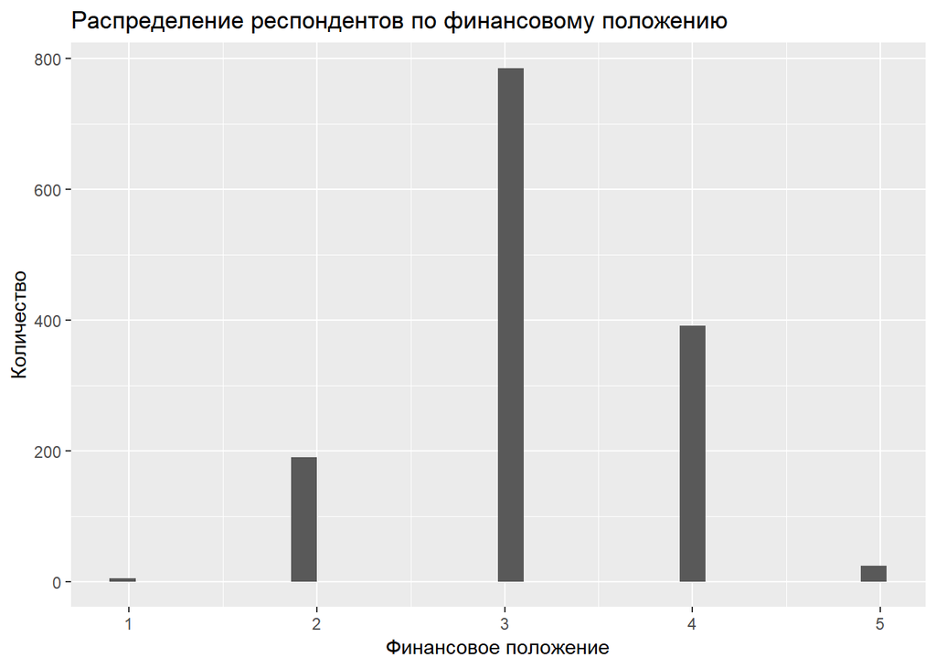

```r
qplot(data = ob, x = FINPOL) +
labs(x ='Финансовое положение', y ='Количество', title = 'Распределение респондентов по финансовому положению')
```

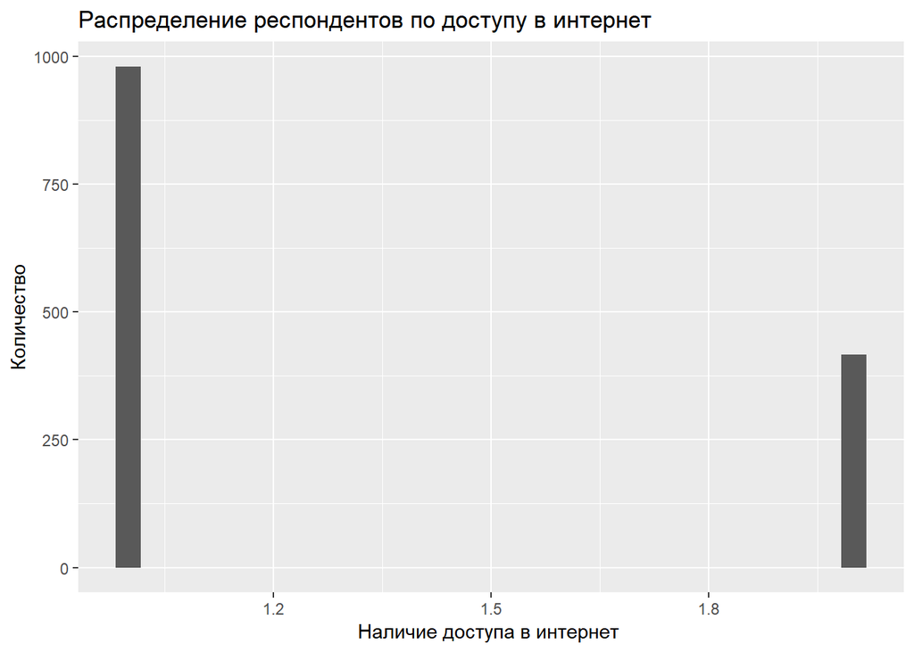

```r
qplot(data = ob, x = DOSINT ) +
labs(x ='Наличие доступа в интернет ', y ='Количество', title = 'Распределение респондентов по доступу в интернет')
```

Построим диаграммы рассеяния для количественных переменных `DOXODSN` (по оси абсцисс) и `NALOG` (по оси ординат) c помощью команды `qplot`

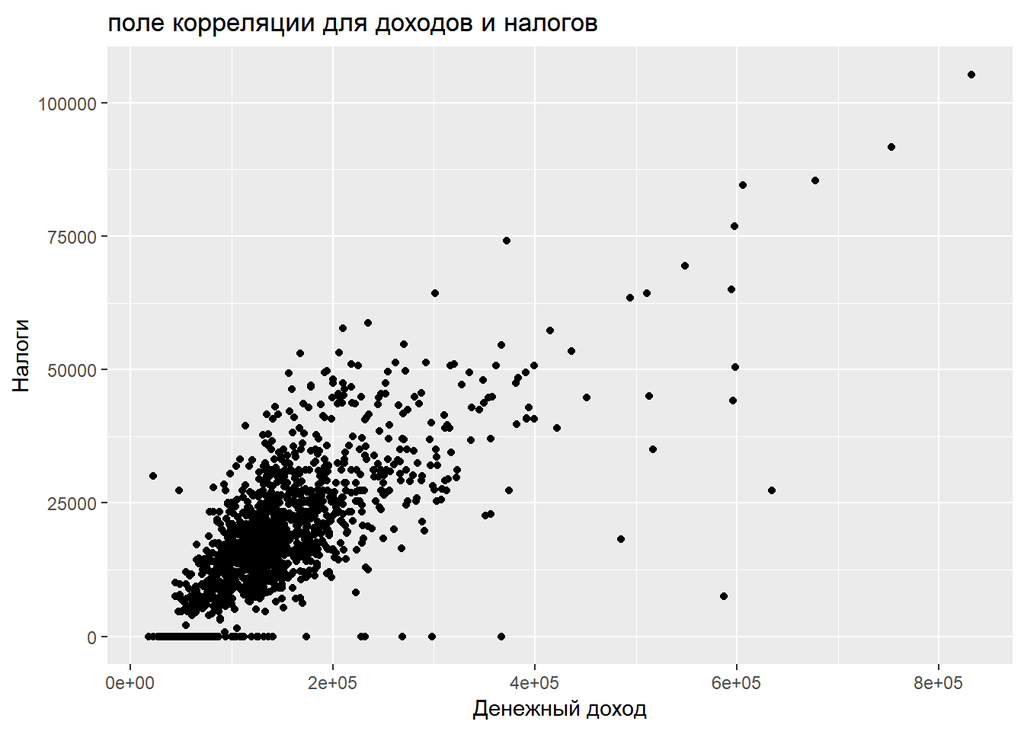

```r
qplot(data = ob, x = DOXODSN, y = NALOG) +
labs(x ='Денежный доход', y = 'Налоги', title = 'поле корреляции для доходов и налогов' )
```

[figure not shown]

```r
qplot(data = ob, x =DOXODSN, y = OBPL ) +
labs(x ='Денежный доход ', y ='Количество', title = 'Распределение респондентов по площади квартиры')
```

Диаграмма рассеяния показывает, что между переменная Располагаемые ресурсы и Площадь квартиры связь слабая (преимущественно точки вытянуты вдоль оси ординат). Это не ожидаемый результат, однако он может быть объяснен тем, что некоторые респонденты получили квартиру благодаря подарку родителей (или по наследству). При этом имеются ярко выраженные аномальные наблюдения (выбросы).

Посмотрим их с использованием скрипичного графика (команда geom_viloin() из пакета ggplot2)

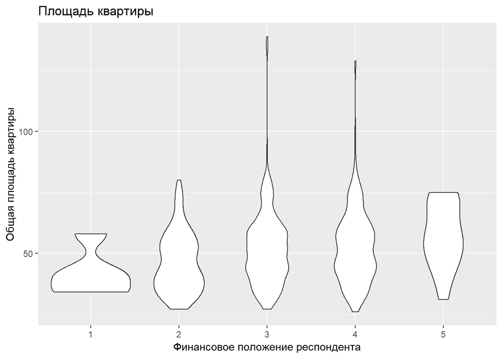

```r
ob <- mutate(ob, FINPOL = factor(FINPOL))
ggplot(data = ob, aes(x=FINPOL, y=OBPL))+
  geom_violin() +
labs(x ='Финансовое положение респондента', y = 'Общая площадь квартиры', title = 'Площадь квартиры' )
```

Посмотрим частость каждой категории

```r
table(ob$FINPOL)
```

```
##
##   1   2   3   4   5
##   5 190 786 391  24
```

Мы видим, что больше всего респондентов, указавших при ответе коды 3 и 4, меньше всего - коды 1 и 5.

Для изучения закона распределения пеерменной РАСПОЛПГПЕМЫЙ ДОХОД построим гистограмму для перменной hist DOXODSN

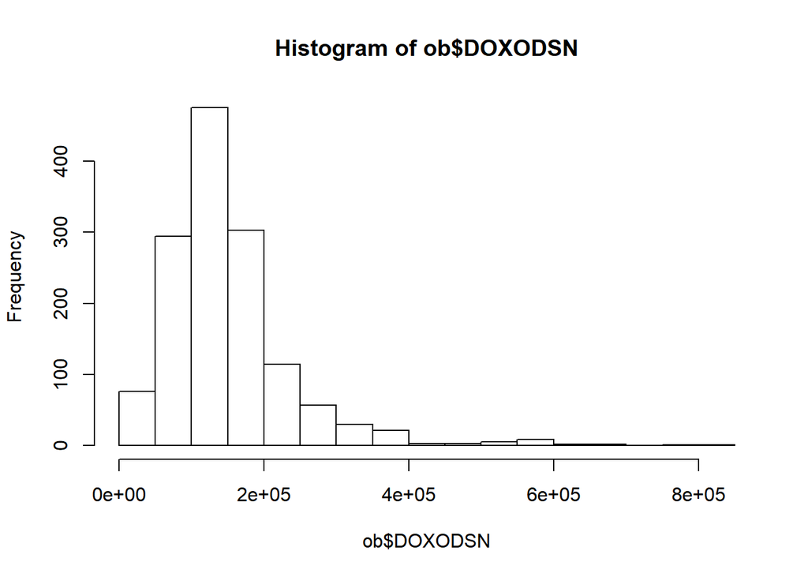

```r
hist(ob$DOXODSN)
```

Денежная переменная имеет ярко выраженную правуостороннюю ассиметрию. Пролагарифмируем ее и построим гистограмму логарифмически нормального закона распределения

Изучим связь между интересующими нас переменными с помощью построения корреляционной матрицы по первым 1000 наблюдениям

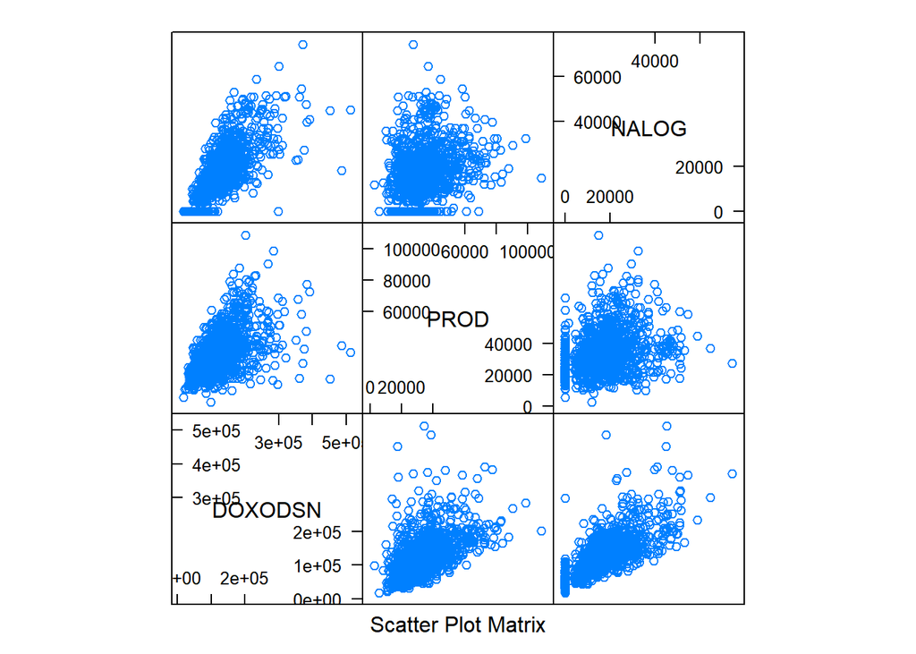

```r
splom(ob[1:1000, c('DOXODSN', 'PROD', 'NALOG')])
```

Отсортируем респондентов по среднедушевому доходу и посмотрим на первые и последние наблюдения.

```r
sorted <- arrange(ob, DOXODN)
sorted
```

```
##      MEST CHLICN   DOXODSN    DOXODN     POTRAS      PROD     NEPROD
## 1       1      3  47534.23  15844.74  262234.23  58977.88  162521.00
## 2       1      2  34138.64  17069.32   34138.64  20581.49    3561.00
## 3       1      2  34647.58  17323.79   34647.58  20640.43    5970.00
## 4       1      1  17435.25  17435.25   17435.25   5808.11    1673.40
## 5       1      2  40004.14  20002.07   40004.14  19759.00    3995.00
## 6       1      2  41050.08  20525.04   38050.08  13247.14    4531.05
## 7       1      2  41237.61  20618.81   41237.61  23621.69    7649.00
## 8       1      2  42369.69  21184.85   39869.69  22757.54    8884.00
## 9       1      1  22065.36  22065.36   20565.36  10934.14    2826.00
## 10      1      2  44352.92  22176.46   35802.92  15218.44    5030.00
## 11      1      2  44501.05  22250.53   36501.05  15073.87    3977.20
## 12      1      1  22359.03  22359.03  232259.03  46208.59  131296.00
## 13      1      2  45888.29  22944.15   45888.29  21776.29   15345.00
## 14      1      2  46736.69  23368.35   46736.69  33283.43    3112.30
```

[output cut: 2779 more lines]

Добавим цвет и построим поле корреляции для пеерменных Доход и Площадь квартиры с учетом пеерменной Финансовое положение (удовлетворенность жинью).

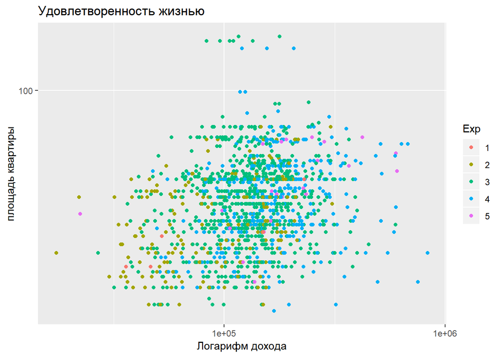

```r
ob3 <- mutate(ob, Exp = factor(FINPOL))

ggplot(data = ob3) +
  geom_point(aes(x = DOXODSN, y = OBPL, color = Exp)) +
  scale_x_log10() +
  scale_y_log10() +
  labs(x = 'Логарифм дохода', y = 'площадь квартиры', title = 'Удовлетворенность жизнью')
```

Анализ рисунка позврляет увидеть, что респонденты, доаольные своим материальным положеним (4- можем позволить все необходимое), в основном, имеют высокий доход, однако площадь их квартиры довольно неоднородна. Т.е респонденты с высокими доходами и могующие себе все позволить зачастую имеют небольшие по площади квартиты.

Посмотрим частость каждой категории

```r
table(ob$FINPOL)
```

```
##
##   1   2   3   4   5
##   5 190 786 391  24
```

Мы видим, что больше всего респондентов, указавших при ответе коды 3 и 4, меньше всего - коды 1 и 5.

Построим рис без логарифмирования перемнных

[figure not shown]

```r
ob3 <- mutate(ob, Exp = factor(FINPOL))

ggplot(data = ob3) +
  geom_point(aes(x = DOXODSN, y = OBPL, color = Exp)) +
  labs(x = 'Логарифм дохода', y = 'площади квартиры', title = 'Удовлетворенность жизнью')
```

Увидим более четкие выбросы для респондентов, назвавших коды 3 и 4. Они имеют более высокие доходы и плащадь квартиры. Построим гистограмму логарифма дохода для каждой категории Финансового положения.

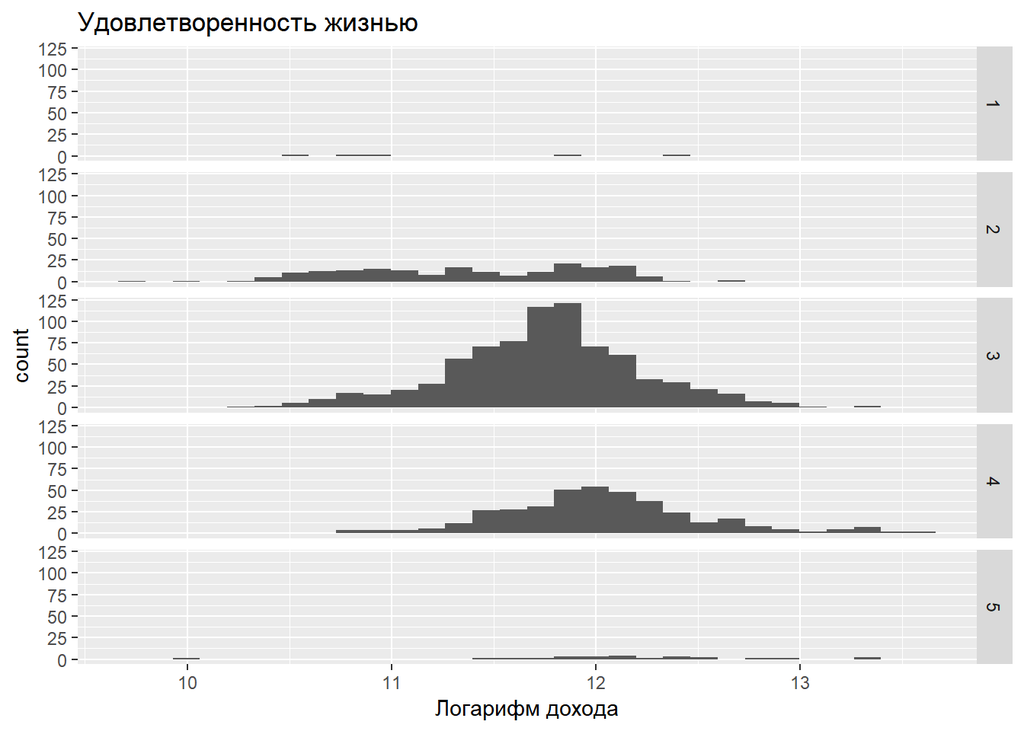

```r
ggplot(data = ob3) +
  geom_histogram(aes(x = log(DOXODSN))) +
  facet_grid(FINPOL ~ .) +
  labs(x = 'Логарифм дохода', title = 'Удовлетворенность жизнью')
```

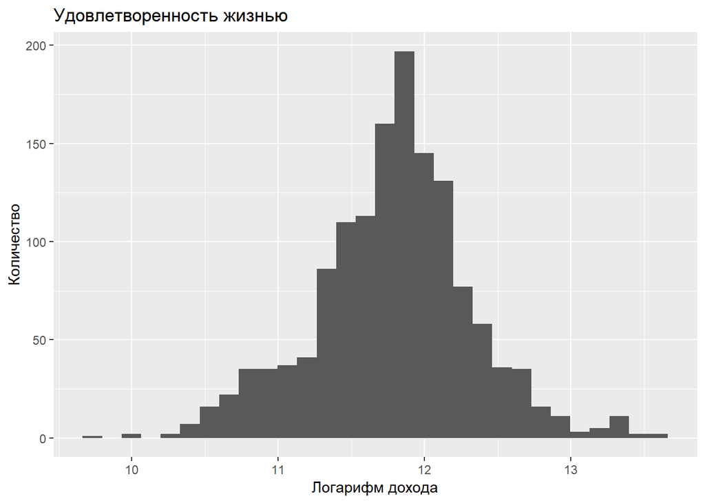

```r
ggplot(data = ob3) +
  geom_histogram(aes(x = log(DOXODSN))) +
  labs(x = 'Логарифм дохода', y = 'Количество', title = 'Удовлетворенность жизнью')
```

[figure not shown]

```r
ggplot(data = ob3) +
  geom_histogram(aes(x = log(OBPL))) +
  facet_grid(FINPOL ~ .) +
  labs(x = 'Логарифм дохода', title = 'Удовлетворенность жизнью')
```

Таким образом, описательный анализ данных позволил увидеть распределение и основные характеристики отобоанных показателей, изучить их связи. :)